# Herramientas para el Análisis de Series de Tiempo en R - Clase 3

Oficina de la CEPAL en Buenos Aires

Octubre 2021

# Introducción

En esta tercera clase vamos a repasar el concepto de estacionariedad y veremos cuáles son los motivos por las cuáles una serie de tiempo puede no serlo. Asimismo, veremos cuáles son las estrategias que podemos adoptar en este último caso, incluida la formulación de un modelo de corrección de errores.

En el módulo práctico, seguiremos nuevamente diez pasos para implementar el test de raíz unitaria y de cointegración, y luego construir un modelo de corrección de errores con fines de pronóstico.

# Módulo conceptual

## Estacionariedad

Si se quiere entender la relación entre dos o más variables a partir del análisis de regresión se necesita dar por sentado algún tipo de estabilidad en el tiempo. Si se permite que la relación entre dos variables cambie de forma arbitraria en cada período no se puede esperar aprender mucho acerca de cómo un cambio en una variable afecta a la otra. Al establecer un modelo de regresión múltiple para datos de series de tiempo se está suponiendo cierta forma de estacionariedad en la que los coeficientes no cambian en el tiempo.

### Definición

Un proceso estocástico que tiene media y varianza finita es estacionario en covarianza si:

1. La **media** es constante:
   $$\begin{align*}
   E(y_{t}) & = \mu \\
   \end{align*}$$
2. La **varianza** es constante:
   $$\begin{align*}
   Var(y_{t}) & = \sigma \\
   \end{align*}$$
3. La **covarianza** entre $y_{t}$ y $y_{t+k}$ depende sólo de la distancia entre los dos términos ($k$), y no de la ubicación del período inicial ($t$):
   $$\begin{align*}
   Cov(y_{t},y_{t+k}) & = \gamma_{s} \\
   \end{align*}$$

Tener presente que:

1. Cuando derivamos los parámetros de la función de regresión muestral con el método de MCO, estos dependían de la media. Si la media de estas variables tendiera a cambiar (como sucede con las series no estacionarias) también tendería a cambiar la relación entre ellas, lo cual se vería reflejado en el valor de los parámetros muestrales.
2. Lo mismo sucede cuando realizamos inferencia estadística para aproximarnos al verdadero valor del parámetro poblacional: para ese procedimiento tomamos un valor constante de la varianza y del desvío estándar.
3. El tercer supuesto hace referencia a lo siguiente: cuando evaluamos la persistencia del componente autorregresivo este no tiene que depender del período muestral que consideremos (cuya ubicación temporal va a estar dada por $t$), sino de la distancia entre $y_t$ y $y_{t+k}$ (dada por $k$). Si para un período muestral la autocorrelación cae rápidamente a medida que $y_{t+k}$ se aleja de $y_t$, lo mismo debería suceder para otro período muestral de la misma serie.

### ¿Cuáles son los motivos por los que una serie puede ser no estacionaria?

**1. Tendencia determinística**

El proceso generador de la serie tiene un componente que es una función no aleatoria del tiempo.

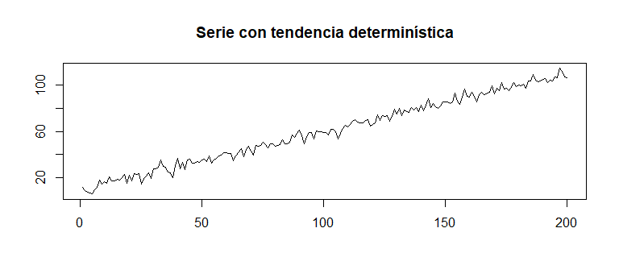

**2. Tendencia estocástica**

El proceso generador de la serie tiene un componente que es una función aleatoria del tiempo. El modelo más conocido que genera una serie con tendencia estocástica es el **Random Walk (o paseo aleatorio)**. Este es un modelo autorregresivo de orden 1 (AR-1), cuyo coeficiente es igual a 1. El hecho de que el coeficiente del componente autorregresivo sea igual a 1 hace que sea una serie con elevada persistencia. La serie eventualmente puede revertir a la media pero al cabo de largos períodos.

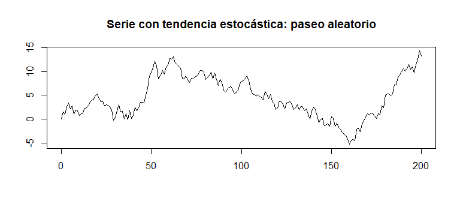

Otro ejemplo de serie con tendencia estocástica es la generada por un modelo **Random Walk with Drift (paseo aleatorio con deriva)**. A diferencia del modelo anterior, este tiene un valor de origen distinto a cero, y dada la persistencia que le da el componente autorregresivo, esto determina que la serie tienda a crecer si la deriva es positiva, y tienda a bajar si la deriva es negativa.

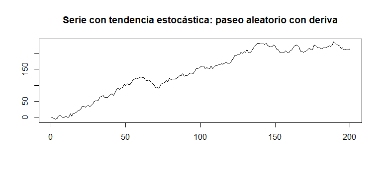

**3. Quiebre estructural**

Ocurre cuando hay cambios discretos (en un momento del tiempo) o graduales (a lo largo de un período) en los parámetros poblacionales del proceso generador de la serie. En series macroeconómicas, estos cambios suelen estar asociados a cambios en la política económica o en la estructura de la economía.

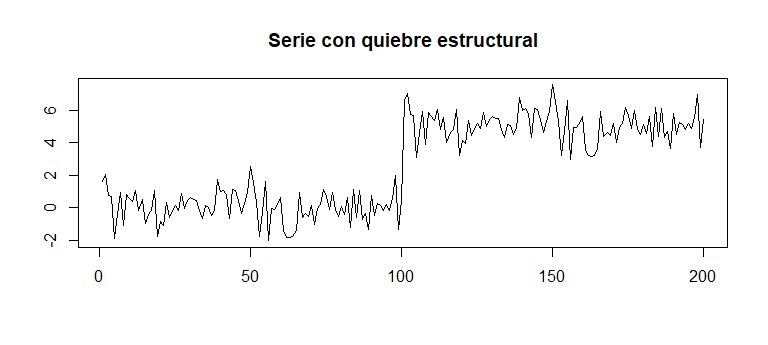

### ¿Cómo saber si una serie no tiene tendencia estocástica?

#### 1. Función de autocorrelación (o correlograma)

Es la correlación de los valores de la variable en $t$ con sus valores pasados (en $t-k$).

$$\begin{align*}
\displaystyle r_{k}=\frac{\Sigma^{T}_{t=k+1} (y_{t}-\overline{y})(y_{t-k}-\overline{y})}{\Sigma^{T}_{t=1}(y_{t}-\overline{y})^{2}}
\\
\end{align*}$$

Si la serie es estacionaria, la función de autocorrelación tiene que caer geométricamente. Si el parámetro autorregresivo es positivo la caída es directa, y si es negativo realizará un movimiento oscilante hasta converger.

**Concepto de dependencia débil:** Una serie de tiempo estacionaria en covarianza es débilmente dependiente si la correlación entre $𝑦_{𝑡}$ y $𝑦_{t+k}$ se vuelve cero con la “suficiente rapidez” cuando $k$ tiende a infinito.

Veamos dos ejemplos…

En el caso de una **serie autorregresiva con raíz menor a 1** (serie estacionaria), la función de autocorrelación cae rapidamente. En cambio, en el caso un **proceso de paseo aleatorio** (serie no estacionaria), la función de autocorrelación cae lentamente.

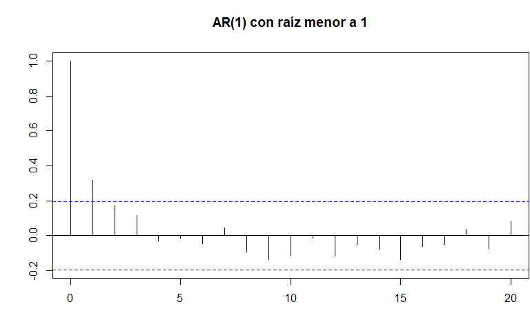

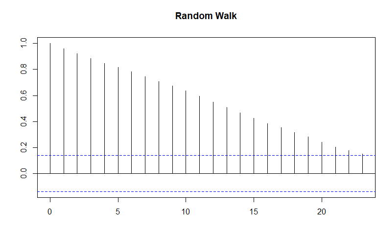

#### 2. Test de Dickey-Fuller

Un test formal para una tendencia estocástica fue propuesto por Dickey y Fuller (1979). Este test evalúa si el coeficiente autorregresivo es igual a 1.

**Test sobre AR(1):**

$$\begin{align*}
𝑦_𝑡=𝛽_0+𝛽_1 𝑦_{𝑡−1}+𝑒_𝑡 \\
\end{align*}$$

Hipótesis nula (tiene raíz unitaria): $𝐻_0: 𝛽_1=1$

Hipótesis alternativa (no tiene raíz unitaria): $𝐻_𝐴: |𝛽_1 |<1$

$$\begin{align*}
\\
\end{align*}$$

**Reescritura del test:**

$$\begin{align*}
Δ𝑦_𝑡=𝛽_0+𝛿𝑦_{𝑡−1}+𝑒_𝑡 \\
\end{align*}$$

Donde: $𝛿=𝛽_1-1$

Hipótesis nula (tiene raíz unitaria): $𝐻_0:𝛿=0$

Hipótesis alternativa (no tiene raíz unitaria): $𝐻_{A}: |𝛿|<0$

$$\begin{align*}
\\
\end{align*}$$

**Test de Dickey-Fuller aumentado:**

En el test de Dickey-Fuller aumentado se controla por los rezagos de $Δ𝑦_{𝑡}$ ante la posible presencia de autocorrelación serial. Según Wooldridge (2012), la cantidad de los rezagos ($𝑝$) está determinada por la frecuencia de los datos. Para datos anuales se suelen considerar uno o dos rezagos, para datos trimestrales cuatro, y para mensuales 12 rezagos. No obstante, no se tienen que seguir reglas estrictas para la determinación de la cantidad de rezagos, y los programas en general incorporan algún método para su estimación automática.

$$\begin{align*}
Δ𝑦_𝑡=𝛽_0+𝛿𝑦_{𝑡−1}+\sum^{p}_{h=1}\Delta𝑦_{𝑡−h}+𝑒_𝑡 \\
\end{align*}$$

Un aspecto importante es que el test de Dickey-fuller no considera la distribución t de Student, sino una especial. Los valores críticos para realizar el test de hipótesis van a ser provistos por el programa lo que va a facilitar el procedimiento. A modo de ejemplo, a continuación se presentan los valores críticos para el caso especial en que no hay tendencia determinística. Notar que el valor crítico en valor absoluto para un nivel de significatividad del 5% es mayor que cuando consideramos una distribución t de Student (|2.86| vs. |1.96|).

| Nivel de significatividad | 1% | 2.5% | 5% | 10% |
| --- | --- | --- | --- | --- |
| Valor crítico | -3.43 | -3.12 | -2.86 | -2.57 |

### ¿Qué hacer cuando una serie es no estacionaria?

#### Curso de acción 1: si es integrada de orden 1 expresar la serie en diferencias

Si la serie es integrada de orden 1 significa que la serie expresada en primera diferencia es estacionaria, por lo que una estrategia sencilla de implementar en ese caso es aplicar el operador diferencia a la variable explicada (o a ambas si fuera el caso de que las dos son integradas de orden 1). Es decir, se va a incluir la variación de la serie y no su nivel original.

$$\begin{align*}
Δ𝑦_𝑡=𝛽_0+𝛽_1 Δ x_{𝑡}+𝑒_𝑡 \\
\end{align*}$$

#### Curso de acción 2: controlar en la regresión por el componente que hace que sea no estacionaria

Ante la presencia de una **tendencia determinística** deberiamos incluir en la regresión una variable que dependa del tiempo.

$$\begin{align*}
𝑦_𝑡=𝛽_0+𝛽_1 x_{𝑡}+𝛽_2 t +𝑒_𝑡 \\
\end{align*}$$

Donde: $t$ es una tendencia determinística

Ante la presencia de un **quiebre estructural** podriamos incluir una variable *dummy* que asuma un valor de cero para el período previo al cambio y de uno para el período posterior. En este caso, lo que cambia es el promedio de la variable explicada.

$$\begin{align*}
𝑦_𝑡=𝛽_0+𝛽_1 x_{𝑡}+𝛽_2 𝜸 +𝑒_𝑡 \\
\end{align*}$$

Donde: $𝜸$ es una *dummy* para quiebre estructural.

Otra alternativa podría ser aplicar la *dummy* al parámetro de algunas de las variables explicativas (término de interacción). En este segundo caso lo que cambia es la pendiente de la relación entre las variables.

$$\begin{align*}
𝑦_𝑡=𝛽_0+𝛽_1𝜸 x_{𝑡} +𝑒_𝑡 \\
\end{align*}$$

Donde: $𝜸$ es una *dummy* para quiebre estructural.

#### Curso de acción 3: evaluar si la variable explicativa y explicada comparten una misma tendencia, es decir, si están cointegradas. En este caso podemos implementar la regresión de una variable sobre la otra sin aplicar ningún tipo de transformación

Cuando $𝑥_𝑡$ y $𝑦_𝑡$ son integradas de orden 1 y hay una combinación lineal entre ellas tal que el residuo de esta combinación es integrado de orden 0 ($𝑒_𝑡=𝑦_𝑡−𝛽_1 𝑥_𝑡$), $𝑥_𝑡$ y $𝑦_𝑡$ están cointegradas. Esto significa que ambas series comparten la misma tendencia estocástica, y por tanto incluir a $𝑥_𝑡$ en la regresión ya permite controlar por esta tendencia.

$$\begin{align*}
𝑦_𝑡=𝛽_0+𝛽_1 x_{𝑡}+𝑒_𝑡 \\
\end{align*}$$

Donde: $𝑦_{𝑡}$ y $𝑥_{𝑡}$ son $𝐼(1)$ y $𝑒_𝑡$ es $𝐼(0)$

### Observación

Cuando la variable explicada es integrada de orden 1 y aplicamos algunas de las estrategias anteriores para controlar por esta tendencia en la regresión, el ajuste medido por el R2 suele dar muy elevado.

Esto no necesariamente significa que elegimos a los mejores predictores, sino que refleja que una parte importante de la variabilidad se encuentra explicada por la tendencia que, explicita o implícitamente estamos incorporando entre las variables explicativas.

Una estrategia alternativa recomendada para evitar una lectura incorrecta del ajuste del modelo es, por ejemplo, restar la tendencia en el caso de las series que presentan tendencia determinística (ver Wooldridge).

## Cointegración y MCE

#### ¿Cómo saber si dos series están cointegrada?

Realizamos el **test de Engle y Granger**. Este test consiste en evaluar si el residuo de una combinación lineal entre las dos variables (conocida con anterioridad o no) es estacionario.

Cuando no conocemos la forma de la relación lineal entre las variables se puede realizar en dos pasos:

- Corremos la regresión de una variable sobre la otra y guardamos el residuo.
- Realizamos un **test de raíz unitaria sobre el residuo** obtenido en el paso anterior. Si se rechaza la hipótesis nula de que ese residuo es integrado de orden 1, entonces tenemos evidencia a favor de que las series están cointegradas.

Si bien los valores críticos utilizados en el test de cointegración no son los mismos que los del test de Dickey-fuller, como estos valores tienden a ser similares se suelen tomar los de Dickey-fuller como aproximación.

#### Relación entre dos variables integradas de orden 1 y cointegradas

**Relación de largo plazo**

Es la que surge de la regresión de las dos variables con sus respectivas tendencias. Esto es, cuando corremos la regresión con las series en sus niveles originales. Este tipo de relación nos interesa cuando queremos obtener parámetros estructurales o hacer proyecciones de mediano-largo plazo.

$$\begin{align*}
𝑦_𝑡=𝛽_0+𝛽_1 x_{𝑡}+𝑒_𝑡 \\
\end{align*}$$

**Relación de corto plazo**

Es la que surge de la regresión de las dos variables habiendo extraído sus respectivas tendencias a partir del operador diferencia. Esta relación capta el efecto contemporáneo de una variable sobre la otra.

$$\begin{align*}
\Delta 𝑦_𝑡=\sigma_0+\sigma_1 \Delta x_{𝑡}+w_𝑡 \\
\end{align*}$$

Sin embargo, esta forma de expresar la relación de corto plazo no es correcta porque no incorpora la relación de largo plazo entre las variables: la variación en cada período de $𝑦_𝑡$ depende no solo de cambios contemporáneos de $𝑥_𝑡$, sino también de cambios en períodos anteriores ($𝑥_{𝑡−𝑗}$) que no alcanzaron a impactar de forma plena en $𝑦_𝑡$.

**Modelo de corrección de errores**

El problema presentado en el punto anterior es lo que da lugar a la necesidad de incorporar un **término corrector al equilibrio de largo plazo** en la ecuación de la relación de corto plazo. Esto es lo que comúnmente se conoce como modelo de corrección de errores.

$$\begin{align*}
\hat{y}_{t}=𝛽_0+𝛽_1 x_{𝑡} \\
\end{align*}$$

$$\begin{align*}
𝑒_𝑡=𝑦_𝑡- \hat{y}_{t} \\
\end{align*}$$

$$\begin{align*}
\Delta 𝑦_𝑡=\gamma_{0}+\gamma_{1} \Delta x_{𝑡}+\gamma_{2}𝑒_{𝑡-1} +u_𝑡 \\
\end{align*}$$

En cada período, $𝑦_{𝑡}$ se mueve en función de cambios en $𝑥_{𝑡}$, pero también en función de desalineamientos de su equilibrio de largo plazo del período anterior.

El coeficiente de largo plazo ($𝛽_1$) suele ser mayor en términos absolutos al de corto plazo ($\sigma_{1}$).

La velocidad a la cual se alcanza el efecto pleno de una variable sobre la otra está dado por el coeficiente $\gamma_{2}$. Este coeficiente siempre tiene que ser negativo.

## Resumen conceptual

- Hay tres factores que pueden explicar que una serie sea no estacionaria: (i) **tendencia determinística**, (ii) **tendencia estocástica**, y (iii) **quiebre estructural**.
- Para saber si una serie tiene tendencia estocástica podemos realizar el **test de Dickey-Fuller**. Otra alternativa menos rigurosa es observar la función de autocorrelación.
- **Cursos de acción frente a series no estacionarias**: (i) si tiene tendencia estocástica y es integrada de orden 1 la podemos expresar en primera diferencia; (ii) si tiene tendencia determinística incorporamos a esta como control en la regresión; (iii) si tiene quiebre estructural incorporamos una dummy en la regresión que valga cero para el período previo al cambio y uno para el período posterior, y que puede incluirse como una constante o como un término de interacción; (iv) si las series con las que queremos trabajar están cointegradas (comparten tendencia) podemos realizar la regresión de una sobre la otra sin ningún tipo de transformación.
- Para saber si dos series están cointegradas podemos realizar el **test de Engle y Granger**, que consiste en implementar un test de raíz unitaria sobre el residuo de la regresión de una de las variables sobre la otra. Si este residuo es estacionario, las series están cointegradas.
- Si nos interesa la relación de corto plazo de series cointegradas debemos incorporar un ajuste corrector al equilibrio. Esto es lo que conocemos como **modelo de corrección de errores**.

# Módulo práctico

## Paso 1. Limpiamos la memoria y cargamos las librerías

Para comenzar limpiamos la memoria de R-studio con el cógido `rm(list=ls())`. Esto va a permitir que el script corra más rápido. Luego vamos a instalar una nueva librería con el código `install.packages()` (fUnitRoots) y abrimos todas aquellas que utilizaremos en esta clase con el código `library()`.

```r
#  Limpiamos la memoria
rm(list=ls())

# Instalamos una nueva librería
#install.packages("fUnitRoots")

# Abrimos librerias
library(tidyverse)
library(readxl)
library(openxlsx)
library(ggplot2)
library(lubridate)
library(forecast)
library(dynlm)
library(fUnitRoots)
library(kableExtra)
```

## Paso 2. Definimos el directorio y cargamos el archivo

Con el código `setwd()` definimos una carpeta desde donde levantaremos los archivos y adonde podremos guardar por default los archivos nuevos que generemos. Luego, con el código `read.xlsx()` levantamos el archivo de Excel con los datos. Dentro de ese código tenemos que especificar el nombre del archivo con su extensión (“Clase 3.xlsx”) y el nombre de la hoja en donde se encuentran los datos que queremos levantar (sheet = “Base1”).

```r
# Definimos directorio
setwd("C:/Users/mcherkasky/Google Drive/CEPAL/Curso series de tiempo/Clase 3")

# Levantamos archivo desde Excel
df <- read.xlsx("Clase 3.xlsx",sheet = "Base1")
```

## Paso 3. Inspeccionamos los datos

Con la función `head()` podemos inspeccionar las primeras observaciones. En este caso le pedimos que nos muestre las primeras 5 observaciones.

```r
# Inspeccionamos las primeras 5 observaciones
head(df,5)
```

```
##   Trimestre      PIB        M     TCRM
## 1     38047 475642.4 76725.67 159.0447
## 2     38139 470200.8 80629.07 153.0250
## 3     38231 493619.5 82343.67 158.4904
## 4     38322 500998.0 87172.73 163.4125
## 5     38412 515549.2 89020.97 162.2566
```

También podemos inspeccionar las últimas observaciones con la función `tail()`. Por ejemplo, nos puede interesar saber cuáles son los últimos datos que tenemos disponibles.

```r
# Inspeccionamos las últimas 5 observaciones
tail(df,5)
```

```
##    Trimestre      PIB        M     TCRM
## 66     43983 556121.2 119109.5 113.9830
## 67     44075 627739.3 131801.0 119.7586
## 68     44166 656108.2 150280.1 121.3178
## 69     44256 674394.7 154402.1 122.4856
## 70     44348 665002.6 162786.0 117.9076
```

## Paso 4. Definimos la variable tiempo

Definimos la variable tiempo con `as.Date()`. No obstante, cuando levantamos un archivo de excel puede darse una inconsistencia entre la numeración de la fecha de ese programa y la de R. Esto es así porque R numera la fecha contando desde 01-01-1970 y Excel desde 1899-12-30. Por este motivo tenemos que indicarle a R en qué fecha comienza la cuenta para una variable fecha traída de Excel.

```r
# Definimos la variable tiempo
df$Trimestre<-as.Date(df$Trimestre, origin = "1899-12-30")
```

## Paso 5. Creamos las variables de series de tiempo

De manera tal de preparar los datos para estimar los modelos, vamos a convertir las variables a series de tiempo. Para ello usamos la función `ts()`. Esta función la podemos aplicar a variables o incluso a una base de datos entera.

```r
# Definimos series de tiempo
PIB <- ts(df$PIB, start=c(2004,1), frequency = 4)
M <- ts(df$M,start=c(2004,1), frequency = 4)
TCRM <- ts(df$TCRM,start=c(2004,1), frequency = 4)
```

## Paso 6. Graficamos las series

Para graficar las series de PIB, importaciones y tipo de cambio real utilizaremos la libreria “ggfortify” con la función `autoplot()`. Esta librería está basada en la conocida librería de “ggplot”. Notar que en el código debemos especificar el nombre del eje horizontal `xlab()`, el nombre del eje vertical `ylab()`, el título del gráfico `ggtitle()`, las especificaciones de la leyenda `guides()` y los nombres de los ejes `labs()`.

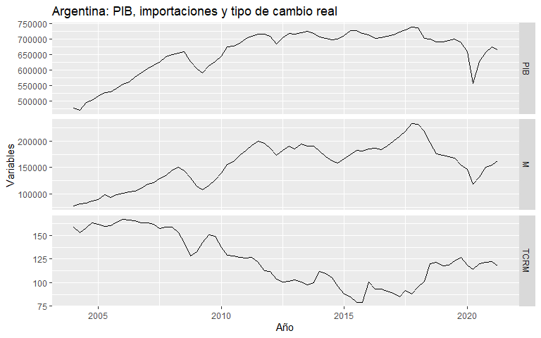

```r
library(ggfortify)
autoplot(cbind(PIB,M,TCRM), facets = TRUE)+
  ggtitle("Argentina: PIB, importaciones y tipo de cambio real") +
  guides(colour=guide_legend(title="Variables"))+
  labs(x = "Año", y = "Variables")
```

## Paso 7. Evaluamos si las series son estacionarias

Una primera estrategia para evaluar si las series son estacionarias es observar su función de autocorrelación. Esto lo podemos realizar a partir de la función `Acf()` o bien a partir de la función `ggAcf()`. Como puede observarse en los gráficos a continuación, la función de autocorrelación decae muy lentamente en los tres casos, lo que sería un primer indicio de que las series no son estacionarias.

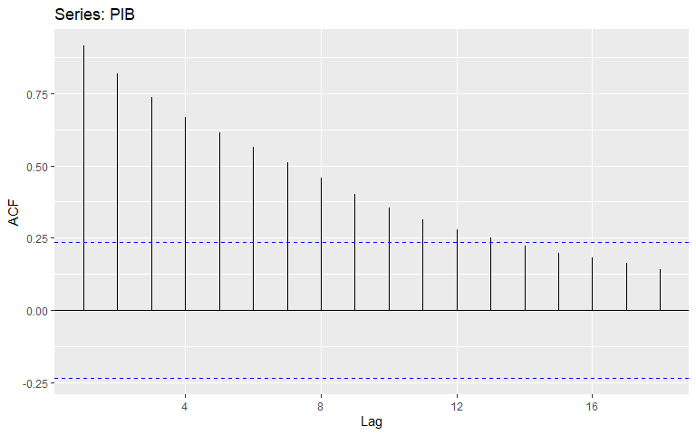

```r
# Graficamos función de autocorrelación (ACF)
ggAcf(PIB)
```

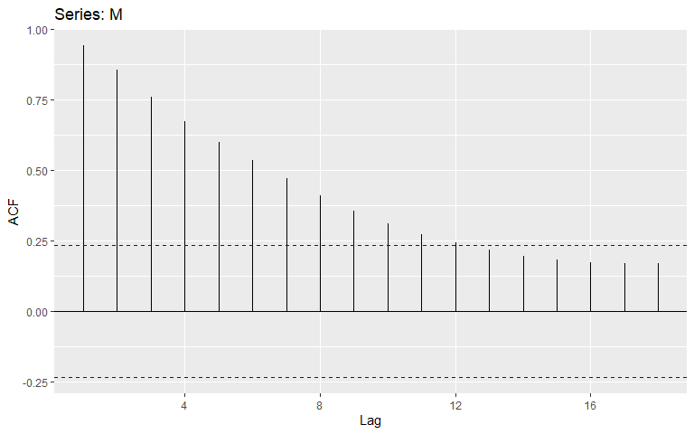

```r
ggAcf(M)
```

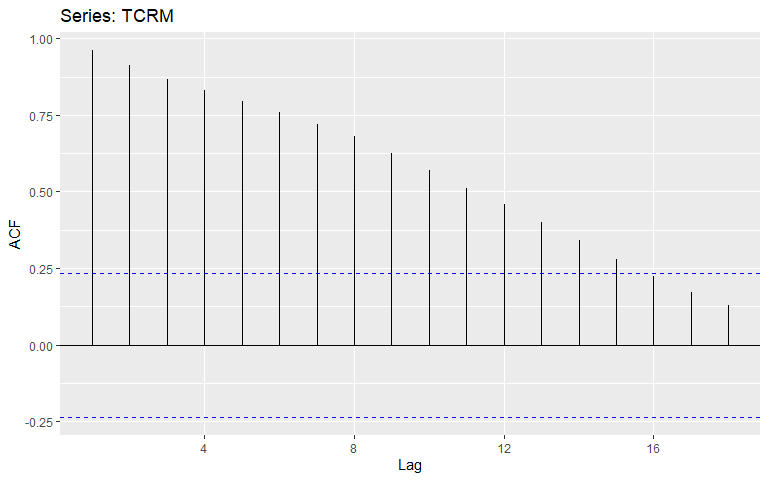

```r
ggAcf(TCRM)
```

Luego realizamos el **test de Dickey-Fuller aumentado** para tener evidencia más robusta a favor de la presencia de series integradas de orden 1. La hipótesis nula es que las series tienen raíz unitaria. Como puede observarse en los resultados más abajo, en ningún caso se rechaza la hipótesis nula: en todos ellos el p-valor es superior al 5% de significatividad.

Notar que en el test incluimos una constante con la opción `type = "c"`. Esto es porque de acuerdo a la inspección visual suponemos que las series siguen un proceso de paseo aleatorio con deriva (no retornan lentamente a su media). También podríamos probar el test sin esa constante (`type = "nc"`). Cuando no está muy claro si debe incluirse o no este término, lo mejor es presentar ambos resultados. Si ambas opciones coinciden en el mismo diagnóstico es evidencia más robusta. Otra alternativa que admite el test es incorporar una tendencia determinística (`type = "ct"`). Recordar que lo que estamos buscando probar con el test de Dickey-Fuller es la presencia de una tendencia estocástica derivada de un componente autorregresivo muy persistente. Esto no incluye la tendencia determinística que depende del tiempo.

Por otro lado, podríamos incluir cuatro rezagos en el test para controlar por autocorrelación por tratarse de series trimestrales (`lags=4`). No obstante, elegimos no incluir esta opción y dejamos que el programa estime automáticamente la cantidad de lags óptima utilizando el AIC.

```r
# Test de raíz unitaria
adfTest(PIB, type = "c")
```

```
##
## Title:
##  Augmented Dickey-Fuller Test
##
## Test Results:
##   PARAMETER:
##     Lag Order: 1
##   STATISTIC:
##     Dickey-Fuller: -2.8878
##   P VALUE:
##     0.05418
##
## Description:
##  Wed Oct 20 13:00:55 2021 by user: MCHERKASKY
```

```r
adfTest(M, type = "c")
```

```
##
## Title:
##  Augmented Dickey-Fuller Test
##
## Test Results:
##   PARAMETER:
##     Lag Order: 1
##   STATISTIC:
##     Dickey-Fuller: -2.3001
##   P VALUE:
##     0.207
##
## Description:
##  Wed Oct 20 13:00:55 2021 by user: MCHERKASKY
```

```r
adfTest(TCRM, type = "c")
```

```
##
## Title:
##  Augmented Dickey-Fuller Test
##
## Test Results:
##   PARAMETER:
##     Lag Order: 1
##   STATISTIC:
##     Dickey-Fuller: -1.4016
##   P VALUE:
##     0.536
##
## Description:
##  Wed Oct 20 13:00:55 2021 by user: MCHERKASKY
```

## Paso 8. Test de cointegración

Una vez que comprobamos que las series tienen raíz unitaria queremos ver si comparten una tendencia común, lo que determinaría que tengan una relación de largo plazo. Para ello implementamos el **test de Engle y Granger**. Este test consiste en comprobar si el residuo de la relación de largo plazo entre las variables es estacionario. Por ello, realizamos la regresión en niveles, obtenemos el residuo, y sobre este hacemos el **test de Dickey-Fuller**. Si bien los valores críticos del test de Engle y Granger no son los mismos que los del Dickey-Fuller, como son similares se los suele tomar como aproximación. En los resultados podemos ver que se rechaza la hipótesis nula a un nivel de significatividad del 5% (p-valor menor al 5%) y por lo tanto esto es evidencia a favor de que el residuo es estacionario y las series están cointegradas.

```r
# Obtenemos el residuo de la relación de largo plazo
res <- ts(dynlm(log(M) ~ log(PIB)+log(TCRM), data = df)$res, start = 2004, frequency = 4)

# Test de Engle y Granger = test de raíz unitaria sobre el residuo de la relación de LP
adfTest(res)
```

```
##
## Title:
##  Augmented Dickey-Fuller Test
##
## Test Results:
##   PARAMETER:
##     Lag Order: 1
##   STATISTIC:
##     Dickey-Fuller: -2.6144
##   P VALUE:
##     0.01
##
## Description:
##  Wed Oct 20 13:00:55 2021 by user: MCHERKASKY
```

## Paso 9. Modelo de corrección de errores

Una vez que comprobamos que las series están cointegradas procedemos a estimar los modelos presentados a continuación:

**Relación de largo plazo**

$\log{M}_𝑡=𝛽_0+𝛽_1 \log{PIB}_{𝑡}+𝛽_2 \log{TCRM}_{𝑡}+𝑒_𝑡$

**Relación de corto plazo**

$\Delta \log{M}_𝑡=\sigma_0+\sigma_1 \Delta \log{PIB}_{𝑡}+\sigma_2 \Delta \log{TCRM}_{𝑡}+w_𝑡$

**Modelo de corrección de errores**

$\log{\hat{M}}_{t}=𝛽_0+𝛽_1 \log{PIB}_{𝑡}+𝛽_2 \log{TCRM}_{𝑡}$

$𝑒_𝑡=\log{M}_𝑡- \log{\hat{M}}_{t}$

$\Delta \log{M}_t=\gamma_{0}+\gamma_{1} \Delta \log{PIB}_{𝑡}+\gamma_{2} \Delta \log{TCRM}_{𝑡}+\gamma_{3}𝑒_{𝑡-1} +u_𝑡$

Luego presentamos los valores de los parámetros muestrales en una tabla resumen. Notar que los parámetros asociados al PIB y al TCRM de largo plazo son mayores que los del MCE (que sólo reflejan el efecto contemporáneo), y que el término corrector al equilibrio tiene signo negativo de acuerdo a lo esperado.

```r
# Estimación de los modelos
mlp <- dynlm(log(M) ~ log(PIB)+log(TCRM))
res <- ts(dynlm(log(M) ~ log(PIB)+log(TCRM), data = df)$res, start = 2004, frequency = 4)

mcp <- dynlm(d(log(M)) ~ d(log(PIB))+d(log(TCRM)))
mce <- dynlm(d(log(M)) ~ d(log(PIB))+d(log(TCRM))+L(res))

# Recupero los coeficientes
mlp<-round(data.frame(coef(summary(mlp))[,1]),2) %>% rbind(.,"")
mcp<-round(data.frame(coef(summary(mcp))[,1]),2) %>% rbind(.,"")
mce<-round(data.frame(coef(summary(mce))[,1]),2)

# Presentación de los coeficientes en una única tabla
tabla<-cbind(mce,mlp,mcp) %>%
  dplyr::rename("MCE"=1,"Modelo LP"=2,"Modelo CP"=3)
rownames(tabla) = c("Intercepto","PIB","TCRM","TCE")

kable(tabla, align=rep('c', 4), format.args = list(big.mark = ".")) %>%
  kable_styling(bootstrap_options = c("striped", "hover"), font_size = 14)
```

|  | MCE | Modelo LP | Modelo CP |
| --- | --- | --- | --- |
| Intercepto | 0.00 | -14.37 | 0 |
| PIB | 1.53 | 2.03 | 1.51 |
| TCRM | -0.10 | -0.19 | -0.16 |
| TCE | -0.22 |  |  |

## Paso 10. Proyección dinámica con el MCE

Por último, realizamos una proyección dinámica fuera de la muestra utilizando el modelo de corrección de errores. En primer lugar, guardamos los parámetros de las estimaciones en vectores, y definimos las variables para todo el período muestral con el que vamos a trabajar (incluye un período para el cual hay datos y otro sobre el cual vamos a proyectar).

```r
# Recuperamos los parámetros de las regresiones
b0<-as.numeric(mlp[1,1])
b1<-as.numeric(mlp[2,1])
b2<-as.numeric(mlp[3,1])

s0<-as.numeric(mce[1,1])
s1<-as.numeric(mce[2,1])
s2<-as.numeric(mce[3,1])
s3<-as.numeric(mce[4,1])

# Definimos las variables de interés
PIB_s <- ts(c(PIB,rep(NA,14)), start=c(2004,1),end=c(2024,4), frequency = 4)
TCRM_s <- ts(c(TCRM,rep(NA,14)), start=c(2004,1),end=c(2024,4), frequency = 4)
M_f <- ts(c(M,rep(NA,14)), start=c(2004,1),end=c(2024,4), frequency = 4)

logM <- log(M_f)
e <- log(M_f)-logM
```

En segundo lugar, estimamos la variable fuera de la muestra y luego graficamos la variable observada y la variable proyectada. La variable proyectada la identificamos con la letra “f”. En nuestra proyección de las importaciones vamos a establecer con fines ilustrativos un escenario de crecimiento del PIB del 2% anual (0,5% trimestral) y un escenario en que el TCRM se mantiene sin cambios. Los escenarios de las variables exógenas los identificamos con la letra “s”. Para este último paso recordar que aplicar la diferencia logarítmica es similar a aplicar la variación porcentual.

$$\begin{align*}
M^{f}_t=\left[ 1+\gamma_{0}+\gamma_{1} \cdot \Delta \log{PIB^{s}_t}+\gamma_{2}\cdot \Delta \log{TCRM^{s}_t}+\gamma_{3} \cdot e_{t-1}\right]\cdot M^{f}_{t-1} \\
\end{align*}$$

$$\begin{align*}
\log{\hat{M}}_𝑡=𝛽_0+𝛽_1 \log{PIB}^{s}_{𝑡}+𝛽_2 \log{TCRM}^{s}_{𝑡} \\
\end{align*}$$

$$\begin{align*}
𝑒_𝑡=\log{M}^{f}_𝑡- \log{\hat{M}}_{t} \\
\end{align*}$$

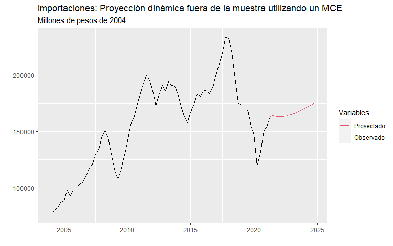

```r
# Realizamos una proyección dinámica fuera de la muestra
for(j in 71:84){

  # Escenarios exógenas
  PIB_s[j] <- (1+0.005)*PIB_s[j - 1]
  TCRM_s[j] <- TCRM_s[j - 1]

  # Proyección del modelo de corrección de errores
  M_f[j] <- (1+s0+s1*(log(PIB_s[j])-log(PIB_s[j-1]))+s2*(log(TCRM_s[j])-log(TCRM_s[j-1]))+
             s3*e[j-1])*M_f[j-1]

  # Relación de largo plazo y desalineamiento respecto al equilibrio de LP
  logM[j] <- b0+b1*log(PIB_s[j])+b2*log(TCRM_s[j])
  e[j] <- log(M_f[j])-logM[j]
}

# Graficamos
autoplot(cbind(M_f,M), facets = FALSE)+
  ggtitle("Importaciones: Proyección dinámica fuera de la muestra utilizando un MCE") +
  labs(x = "", y = "", subtitle="Millones de pesos de 2004") +
  guides(colour=guide_legend(title="Variables"))+
  scale_color_manual(labels = c("Proyectado","Observado"), values = c(2, 1))
```

# Referencias

- **Enders**, W. (2008). Applied econometric time series. John Wiley & Sons.
- **Hyndman**, R.J., & **Athanasopoulos**, G. (2018). Forecasting: principles and practice, 2nd edition, OTexts: Melbourne, Australia. OTexts.com/fpp2.
- **Wooldridge**, J. M. (2015). Introductory econometrics: A modern approach. Cengage learning.